# Apology Assignment

# Task 1

## Step 1: Clean Data

In the raw data for this survey, there are originally 61 unique responses recorded (n = 61). Reviewing the data, one respondent (ID: R_bBJ75JWs3W8KSgF) was removed due to withdrawn consent and 12 respondents were removed due to vastly incomplete data and failed attention checks. In this data set there are two responses that are valuable but must be proceeded with caution. Respondent ID: R_3LfYCLoxkitDLMZ failed the attention check but the rest of the data is complete and adequate, there appears to have been a misunderstanding with how to answer the attention check, therefore this respondent has been left in to enrich the data. Respondent ID: R_1pRoB3KkAH3DjCD only has incomplete responses in the demographic section, yet has adequate and complete responses for the rest of the survey. After cleaning the data, the final set includes 48 unique responses (n = 48).

```r
library(tidyr)
library(ggplot2)
library(dplyr)
Cleaned_data <- read.csv("Cleaned_data.csv")
data_copy <- Cleaned_data
```

## Q1: Do People Care About a Return Apology?

```r
t.test(data_copy$feelings_youalone, data_copy$feelings_bothyoufirst, paired = TRUE)
```

```
    Paired t-test

data:  data_copy$feelings_youalone and data_copy$feelings_bothyoufirst
t = -12.789, df = 47, p-value < 2.2e-16
alternative hypothesis: true mean difference is not equal to 0
95 percent confidence interval:
 -29.89689 -21.76978
sample estimates:
mean difference
      -25.83333
```

```r
mean_youalone <- round(mean(data_copy$feelings_youalone),2)
mean_bothyoufirst <- round(mean(data_copy$feelings_bothyoufirst),2)

cat("Average feelings score for 'No Return Apology':", mean_youalone, "\n")
```

```
Average feelings score for 'No Return Apology': -18.4
```

```r
cat("Average feelings score for 'Return Apology':", mean_bothyoufirst, "\n")
```

```
Average feelings score for 'Return Apology': 7.44
```

In the return apology scenario, individuals reported significantly more positive average feelings (7.44) compared to the scenario where individuals received no return apology (-18.4). The Paired T-test reveals that this difference is statistically significant as the p-value < .05. Therefore, this data supports the alternative hypothesis that a return apology has an influence on feelings, suggesting people care about receiving a return apology.

### Return Apology Visualization

[output not shown]

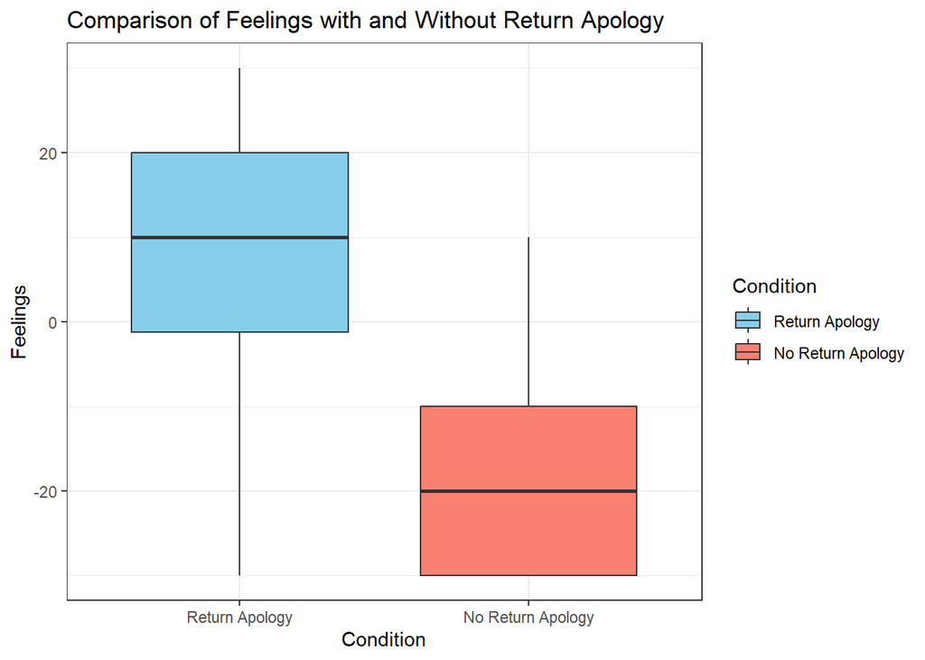

```r
return_apology <- gather(data_copy, variable, value, feelings_youalone, feelings_bothyoufirst)

ggplot(return_apology, aes(x = variable, y = value, fill = variable)) +
  geom_boxplot() +
  scale_x_discrete(labels = c("Return Apology", "No Return Apology")) +
  labs(title = "Comparison of Feelings with and Without Return Apology",
       x = "Condition", y = "Feelings",
       fill = "Condition") +
  scale_fill_manual(values = c("skyblue", "salmon"),
                    labels = c("Return Apology", "No Return Apology")) +
  theme_bw()
```

This visualization further depicts the magnitude of significant difference in feelings between receiving a return apology vs. receiving no return apology. It is apparent that respondents have a much more positive reaction to receiving a return apology, while the sentiment for no return apology is extremely negative.

## Q2: Does this vary as a function of Initiator Type?

### Magnitude of shift in feeling across Initiator Types

To measure the magnitude of shift in feelings, I transformed the data so all values can be positive in order to appropriately understand the direction and effect of the feelings between initiator types. It is important to proceed with caution when analyzing for initiator types as the sample size is a limitation to this analysis. Each initiator type is below a threshold of 30 respondents (always n=22, conditional n=16, never n=10), while this can provide useful insight, generalizing these results to the population may not provide full accuracy.

```r
return_apology$initiator_type <- as.factor(return_apology$initiator_type)
positive_data_copy <- data_copy %>%
  mutate(feelings_youalone_shifted = feelings_youalone + 30,
         feelings_bothyoufirst_shifted = feelings_bothyoufirst + 30)

positive_data_copy <- positive_data_copy %>%
  mutate(sentiment_difference = feelings_bothyoufirst_shifted - feelings_youalone_shifted)

anova <- aov(sentiment_difference ~ initiator_type, data = positive_data_copy)
summary(anova)
```

```
               Df Sum Sq Mean Sq F value Pr(>F)
initiator_type  2    158   79.11   0.394  0.677
Residuals      45   9046  201.03
```

For this analysis, a one-way ANOVA test was used to compare means for multiple intitator types. The analysis depicts that p-value (0.677) > alpha (0.05) for the shift in feelings across initiator types, suggesting that there is no significant difference in the magnitude of shift in feelings in the scenario of receiving a return apology compared to receiving no return apology among the initiator types.

### Difference in feelings for apology conditions across Initiator Types

```r
anova_no_return <- aov(feelings_youalone ~ initiator_type, data = data_copy)

cat("\nANOVA results for No Return Apology:\n ")
```

```
ANOVA results for No Return Apology:
```

```r
summary(anova_no_return)
```

```
               Df Sum Sq Mean Sq F value Pr(>F)
initiator_type  2    915   457.7   3.775 0.0305 *
Residuals      45   5456   121.2
---
Signif. codes:  0 '***' 0.001 '**' 0.01 '*' 0.05 '.' 0.1 ' ' 1
```

```r
cat("\nTukey Test results for No Return Apology:\n")
```

```
Tukey Test results for No Return Apology:
```

```r
TukeyHSD(anova_no_return)
```

```
  Tukey multiple comparisons of means
    95% family-wise confidence level

Fit: aov(formula = feelings_youalone ~ initiator_type, data = data_copy)

$initiator_type
                        diff        lwr        upr     p adj
conditional-always -9.602273 -18.370571 -0.8339745 0.0289434
never-always       -6.827273 -17.005180  3.3506346 0.2454416
never-conditional   2.775000  -7.982752 13.5327520 0.8071224
```

```r
anova_yes_return <- aov(feelings_bothyoufirst ~ initiator_type, data = data_copy)

cat("\nANOVA results for Return Apology:\n")
```

```
ANOVA results for Return Apology:
```

```r
summary(anova_yes_return)
```

```
               Df Sum Sq Mean Sq F value Pr(>F)
initiator_type  2   1313   656.4   3.464 0.0399 *
Residuals      45   8527   189.5
---
Signif. codes:  0 '***' 0.001 '**' 0.01 '*' 0.05 '.' 0.1 ' ' 1
```

```r
cat("\nTukey Test results for Return Apology:\n")
```

```
Tukey Test results for Return Apology:
```

```r
print(TukeyHSD(anova_yes_return))
```

```
  Tukey multiple comparisons of means
    95% family-wise confidence level

Fit: aov(formula = feelings_bothyoufirst ~ initiator_type, data = data_copy)

$initiator_type
                         diff       lwr       upr     p adj
conditional-always  -9.840909 -20.80250  1.120683 0.0863920
never-always       -11.390909 -24.11471  1.332890 0.0875143
never-conditional   -1.550000 -14.99869 11.898686 0.9579414
```

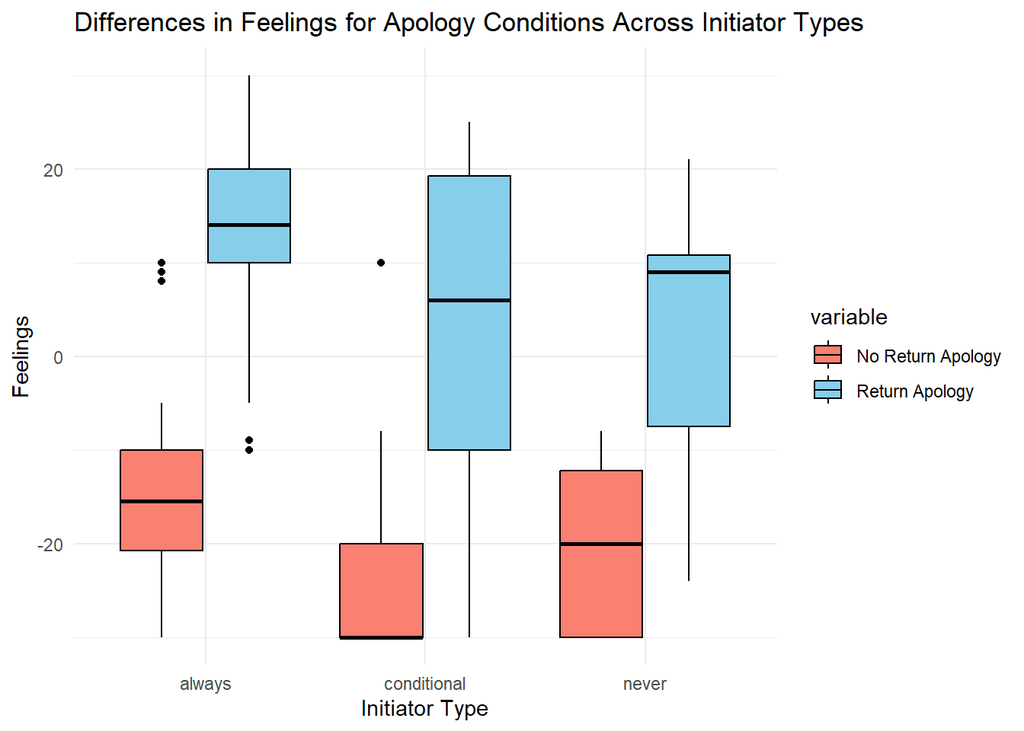

```r
data_long <- reshape2::melt(data_copy, id.vars = "initiator_type",
                            measure.vars = c("feelings_youalone", "feelings_bothyoufirst"))

ggplot(data_long, aes(x = initiator_type, y = value, fill = variable)) +
  geom_boxplot(position = position_dodge(width = 0.8), color = "black") +
  labs(title = "Differences in Feelings for Apology Conditions Across Initiator Types",
       x = "Initiator Type", y = "Feelings") +
  scale_fill_manual(values = c("salmon", "skyblue"),
                    labels = c("No Return Apology", "Return Apology")) +
  theme_minimal()
```

To measure the difference in feelings in each scenario (no return apology and return apology) between initiator types, a ANOVA test was used to compare the means. For the no return apology scenario, the p-value (.0305) < alpha (.05) depicting that there is a significant difference between feelings across initiator types. A Tukey test was conducted to compare specific initiator types against each other. This analysis shows that in a scenario when no return apology is offered, there is a significant difference (p-value = 0.03) in feelings between those always willing to apologize firsts and those that would only be willing to apologize expecting a return apology.

For the return apology scenario, the p-value (.0399) < alpha (.05) indicating that there is a significant difference between feelings across initiator types. The Tukey analysis depicts that there are no significant differences between types as the p-values are above the threshold of .05; however, the always-conditional comparison (p=.086) and always-never type comparison (p=.087) are close to the threshold. The average magnitude in these comparisons are quite high for the small sample size provided, this requires further investigation with a larger sample size.

## Q3: Is a Return Apology the same as Forgiving?

```r
t.test(data_copy$feelings_youaloneforgiven, data_copy$feelings_bothyoufirst, paired = TRUE)
```

```
    Paired t-test

data:  data_copy$feelings_youaloneforgiven and data_copy$feelings_bothyoufirst
t = -7.9255, df = 47, p-value = 3.291e-10
alternative hypothesis: true mean difference is not equal to 0
95 percent confidence interval:
 -25.78191 -15.34309
sample estimates:
mean difference
       -20.5625
```

```r
mean_feelings_youaloneforgiven <- mean(data_copy$feelings_youaloneforgiven)

cat("Average feelings score for 'Offering Forgiveness':", mean_feelings_youaloneforgiven, "\n")
```

```
Average feelings score for 'Offering Forgiveness': -13.125
```

```r
cat("Average feelings score for 'Return Apology':", mean_bothyoufirst, "\n")
```

```
Average feelings score for 'Return Apology': 7.44
```

In the return apology scenario, individuals on average reported significantly more positive feelings (7.44) compared to the scenario where individuals received forgiveness (-13.125). The Paired T-test reveals that this difference is statistically significant as the p-value < .05. Therefore, this data supports the alternative hypothesis that receiving forgiveness is not viewed the same as a return apology.

# Task 2

## Q1: Average Feelings Visualization

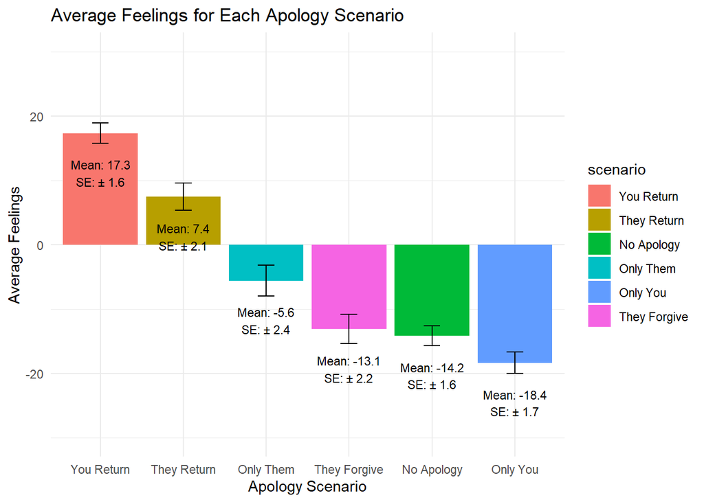

```r
all_scenarios <- c("feelings_youalone","feelings_bothyoufirst","feelings_themalone","feelings_boththemfirst","feelings_neither","feelings_youaloneforgiven")

mean_scenarios <- colMeans(data_copy[, all_scenarios])
se_scenarios <- apply(data_copy[, all_scenarios], 2, sd) / sqrt(nrow(data_copy))

scenarios_df <- data.frame(
  scenario = names(mean_scenarios),
  mean = mean_scenarios,
  se = se_scenarios
)
scenarios_df$scenario <- as.factor(scenarios_df$scenario)

levels(scenarios_df$scenario) <- c("You Return", "They Return", "No Apology","Only Them", "Only You", "They Forgive")

ggplot(scenarios_df, aes(x = reorder(scenario, -mean), y = mean, fill = scenario)) +
  geom_bar(stat = "identity", position = "dodge") +
  geom_errorbar(aes(ymin = mean - se, ymax = mean + se), width = 0.2, position =   position_dodge(0.9)) +
  geom_text(aes(label = paste0("Mean: ",round(mean, 1), "\nSE: ± ", round(se, 1))),
            position = position_dodge(0.9), vjust = 2, size = 3) +
  labs(title = "Average Feelings for Each Apology Scenario",
       x = "Apology Scenario",
       y = "Average Feelings") +
  theme_minimal()+ ylim(-30, 30)
```

The graph depicts that on average, return apologies elicit positive feelings, compared to more negative feelings evoked when only one party apologizes. This also illustrates how the other party taking initiative appears to reduce negative feelings; however, when the other party offers forgiveness, it elicits a similar magnitude of negative feelings as no parties apologizing.

## Q2: Difference in feelings across apology scenarios

```r
all_scenarios <- c("feelings_youalone", "feelings_bothyoufirst", "feelings_themalone",
                   "feelings_boththemfirst", "feelings_neither", "feelings_youaloneforgiven")

stacked_data <- stack(data_copy[, all_scenarios])

colnames(stacked_data) <- c("Feelings", "Scenario")

all_scenario_anova <- aov(Feelings ~ Scenario, data = stacked_data)

# Print ANOVA summary
summary(all_scenario_anova)
```

```
             Df Sum Sq Mean Sq F value Pr(>F)
Scenario      5  47059    9412   51.09 <2e-16 ***
Residuals   282  51945     184
---
Signif. codes:  0 '***' 0.001 '**' 0.01 '*' 0.05 '.' 0.1 ' ' 1
```

```r
TukeyHSD(all_scenario_anova)
```

```
  Tukey multiple comparisons of means
    95% family-wise confidence level

Fit: aov(formula = Feelings ~ Scenario, data = stacked_data)

$Scenario
                                                       diff        lwr
feelings_bothyoufirst-feelings_youalone           25.833333  17.883898
feelings_themalone-feelings_youalone              12.791667   4.842231
feelings_boththemfirst-feelings_youalone          35.708333  27.758898
feelings_neither-feelings_youalone                 4.229167  -3.720269
feelings_youaloneforgiven-feelings_youalone        5.270833  -2.678602
feelings_themalone-feelings_bothyoufirst         -13.041667 -20.991102
feelings_boththemfirst-feelings_bothyoufirst       9.875000   1.925564
feelings_neither-feelings_bothyoufirst           -21.604167 -29.553602
feelings_youaloneforgiven-feelings_bothyoufirst  -20.562500 -28.511936
feelings_boththemfirst-feelings_themalone         22.916667  14.967231
feelings_neither-feelings_themalone               -8.562500 -16.511936
feelings_youaloneforgiven-feelings_themalone      -7.520833 -15.470269
feelings_neither-feelings_boththemfirst          -31.479167 -39.428602
feelings_youaloneforgiven-feelings_boththemfirst -30.437500 -38.386936
feelings_youaloneforgiven-feelings_neither         1.041667  -6.907769
                                                         upr     p adj
feelings_bothyoufirst-feelings_youalone           33.7827690 0.0000000
feelings_themalone-feelings_youalone              20.7411024 0.0000861
feelings_boththemfirst-feelings_youalone          43.6577690 0.0000000
feelings_neither-feelings_youalone                12.1786024 0.6474220
feelings_youaloneforgiven-feelings_youalone       13.2202690 0.4027083
feelings_themalone-feelings_bothyoufirst          -5.0922310 0.0000575
feelings_boththemfirst-feelings_bothyoufirst      17.8244357 0.0056706
feelings_neither-feelings_bothyoufirst           -13.6547310 0.0000000
feelings_youaloneforgiven-feelings_bothyoufirst  -12.6130643 0.0000000
feelings_boththemfirst-feelings_themalone         30.8661024 0.0000000
feelings_neither-feelings_themalone               -0.6130643 0.0264482
feelings_youaloneforgiven-feelings_themalone       0.4286024 0.0754940
feelings_neither-feelings_boththemfirst          -23.5297310 0.0000000
feelings_youaloneforgiven-feelings_boththemfirst -22.4880643 0.0000000
feelings_youaloneforgiven-feelings_neither         8.9911024 0.9990152
```

There are statistically significant differences in feelings across the various scenarios, supported by the ANOVA model’s p-value < . 001. The pairwise comparison indicates that reciprocal apologies are statistically significant and tend to generate more positive feelings when compared to scenarios without apologies or with one-sided apologies.

## Q3: Proportion of people choosing different options

### Preferred Outcome Visualization

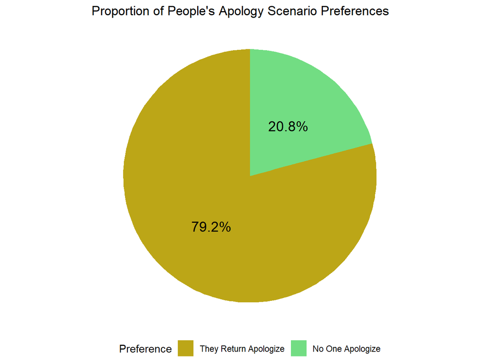

```r
proportions <- data_copy %>%
  count(outcome_binary1) %>%
  mutate(proportion = n / sum(n))

ggplot(proportions, aes(x = "", y = proportion, fill = outcome_binary1)) +
  geom_bar(stat = "identity", width = 1) +
  coord_polar("y", start = 0) +
  labs(title = "Proportion of People's Apology Scenario Preferences",
       fill = "Preference") +
  theme_void() +
  theme(legend.position = "bottom") +
  scale_fill_manual(values = c("#Bca617", "#72dd83"),
                    labels = c("They Return Apologize", "No One Apologize")) +
  geom_text(
    aes(label = paste0(round(proportion * 100, 1), "%")),
    position = position_stack(vjust = 0.5),
    size = 5
  )
```

### Significance Testing

```r
pref_table <- table(data_copy$outcome_binary1)

chi_squared_pref <- chisq.test(pref_table)

chi_squared_pref
```

```
    Chi-squared test for given probabilities

data:  pref_table
X-squared = 16.333, df = 1, p-value = 5.312e-05
```

Conducting a chi-squared goodness of fit test to evaluate distribution, the results show that since the p-value < .001, we reject the null hypothesis, giving evidence to suggest that there is significant differences in the distribution of response across categories. The pie chart shows that 79.2% of respondents prefer a return apology after apologizing compared to no apology from either party, supporting the previous data assessing feelings across scenarios.